# 02_Assignment_Brown.RMD

Binta Brown

9/05/2019

Obtained the necessary libraries: `knitr`, `tidyverse`, `plotly`, and `Metrics`.

```r
## Clear Environment
rm(list=ls())
## Get tidyverse library
library(tidyverse)
load("pd.Rdata")
```

```r
load("/Users/BBrown/Desktop/8200/LLO8200-master/pd.Rdata")
```

```r
## Full explanation of data in codebook
load("pd_lab_explain.Rdata")

#or use View
View(lab_explain)
```

##Question 1 Calculate the mean of the outcome.

I piped the the data loaded to the `summarize` function to view the unconditional avergae of the homeownership rate variable, `homewon_rate`, which I found using the the `mean` fucntion

```r
pd%>%summarize(mean_homeown_rate=mean(homeown_rate,na.rm=TRUE))
```

```
## # A tibble: 1 x 1
##   mean_homeown_rate
##               <dbl>
## 1              72.7
```

## Question 2

Use your mean as a prediction. Create a new variable that consists of the mean of the outcome

To create a new variable, I piped the data to the `mutate` fucntion and added `mean_homeown_rate` as a new column in my original dataset `pd`

```r
pd<-pd%>%mutate(mean_homeown_rate=mean(homeown_rate,na.rm=TRUE))
```

## Question 3

Calculate a summary measure of the errors for each observation—the difference between your prediction and the outcome.

Every observation in my dataset now has the same value of 72.74%, I can now calculate the error for each observation, that is, how far each county’s homewonership rate is from the mean, that is, 72.74%. So now, I subtracted the `mean_homeown_rate` from each individual county’s `homeown_rate`.

```r
pd<-pd%>%mutate(error1=(homeown_rate-mean_homeown_rate))
```

To see far how far off this unconditional prediction was, I calculated the root mean sqaured error (RMSE).

```r
## RMSE

rmse_uncond_mean<-rmse(pd$homeown_rate,pd$mean_homeown_rate)

rmse_uncond_mean
```

```
## [1] 7.653637
```

This RMSE indicates that the unconditional mean is off by 7.65%

## Question 4

Calculate the mean of the outcome at levels of a predictor variable.

I selected `house_unit_multi` into four levels using the `ntile` function and added it as a variable using `mutate`

```r
pd<-pd%>%mutate(house_unit_multi_level=ntile(house_unit_multi,4))
table(pd$house_unit_multi_level)
```

```
##
##   1   2   3   4
## 772 772 772 772
```

I then grouped data by house_unit_multi_level, calculated the `pred_homewon_rate` for each level and then ranked them in descending order.

```r
pd<-pd%>%group_by(house_unit_multi_level)%>% ## Group by predictor
  ##Calculate mean at each level of predictor
  mutate(pred_homeown_rate=mean(homeown_rate))%>%
  ## Ungroup
  ungroup()%>%
  #Rank by prediction, with ties sorted randomly
  mutate(pred_homeown_rate_rank=rank(-pred_homeown_rate,ties.method="random"))
```

## Question 5

Use these conditional means as a prediction: for every county, use the conditional mean to provide a ‘’best guess” as to that county’s level of the outcome.

I view the counties and sort them by `pred_homeown_rate_rank`

```r
pd%>%select(county,house_unit_multi,house_unit_multi_level,pred_homeown_rate, pred_homeown_rate_rank)%>%View()
```

Those who live in multi-level homes, 2 or more, have a less likelihood of owning homes.

To visualize this as a plot, I used the `ggplot` function.

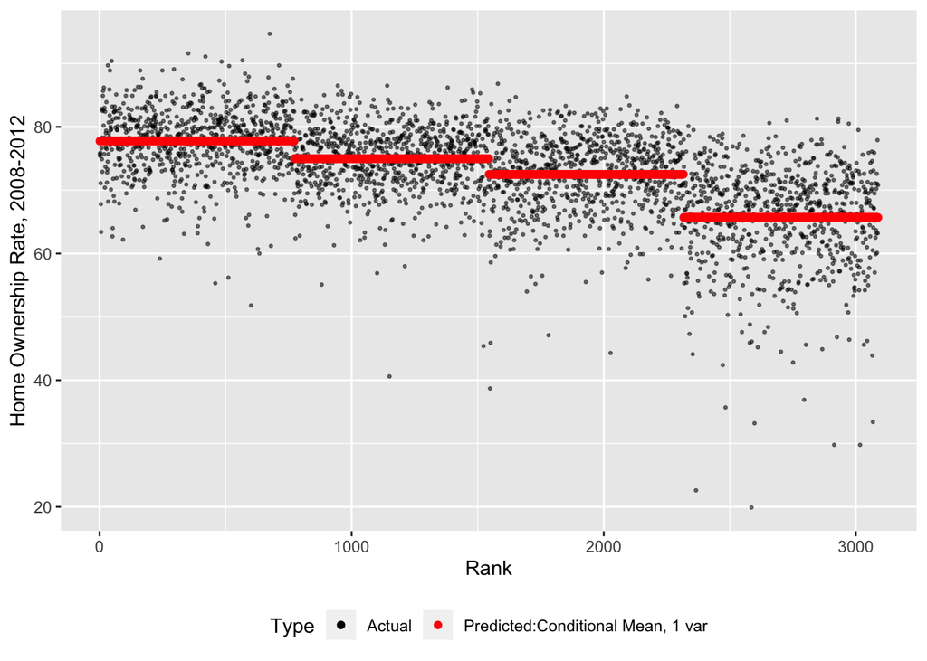

```r
gg<-ggplot(data=pd,aes(x=pred_homeown_rate_rank,y=homeown_rate,color="Actual"))
gg<-gg+geom_point(alpha=.5,size=.5)
gg<-gg+geom_point(aes(x=pred_homeown_rate_rank,y=pred_homeown_rate,color="Predicted:Conditional Mean, 1 var"))
gg<-gg+ scale_color_manual("Type",values=c("Predicted:Conditional Mean, 1 var"="red","Actual"="black"))
gg<-gg+theme(legend.position="bottom")
gg<-gg+xlab("Rank")+ylab("Home Ownership Rate, 2008-2012")
gg
```

# Question 6

Calculate a summary measure of the error in your predictions.

```r
pd <- pd%>%mutate(error1=pred_homeown_rate-mean_homeown_rate)
rmse_cond_mean <- rmse(pd$pred_homeown_rate,pd$mean_homeown_rate)
rmse_cond_mean
```

```
## [1] 4.47162
```

To determine the amount of improvement to my RMSE by adding the new predictor, that is, `house_unit_multi_level`, I substracted the two values.

##Difference btw rmse_uncond and rmse_cond

```r
rmse_difference <- rmse_uncond_mean-rmse_cond_mean
round(rmse_difference, 2)
```

```
## [1] 3.18
```

```r
rmse_percent_improved <- (rmse_difference/rmse_uncond_mean)*100
round(rmse_percent_improved, 2)
```

```
## [1] 41.58
```